# Risk Factor Analysis

## Outcome Variable

**Outcome Variable:** swasted

## Predictor Variables

**Intervention Variable:** parity

**Adjustment Set:**

- arm
- W_mage
- meducyrs
- feducyrs
- hhwealth_quart
- hfoodsec
- W_mhtcm
- vagbrth
- W_nrooms
- impfloor
- impsan
- safeh20
- delta_W_mage
- delta_meducyrs
- delta_feducyrs
- delta_hhwealth_quart
- delta_hfoodsec
- delta_W_mhtcm
- delta_vagbrth
- delta_W_nrooms
- delta_impfloor
- delta_impsan
- delta_safeh20

## Stratifying Variables

The analysis was stratified on these variable(s):

- agecat
- studyid
- country

## Data Summary

| agecat | studyid | country | parity | swasted | n_cell | n |
| --- | --- | --- | --- | --- | --- | --- |
| Birth | ki1000304b-SAS-CompFeed | INDIA | 1 | 0 | 39 | 166 |
| Birth | ki1000304b-SAS-CompFeed | INDIA | 1 | 1 | 2 | 166 |
| Birth | ki1000304b-SAS-CompFeed | INDIA | 2 | 0 | 43 | 166 |
| Birth | ki1000304b-SAS-CompFeed | INDIA | 2 | 1 | 1 | 166 |
| Birth | ki1000304b-SAS-CompFeed | INDIA | 3+ | 0 | 79 | 166 |
| Birth | ki1000304b-SAS-CompFeed | INDIA | 3+ | 1 | 2 | 166 |
| Birth | ki1101329-Keneba | GAMBIA | 1 | 0 | 141 | 1292 |
| Birth | ki1101329-Keneba | GAMBIA | 1 | 1 | 1 | 1292 |
| Birth | ki1101329-Keneba | GAMBIA | 2 | 0 | 133 | 1292 |
| Birth | ki1101329-Keneba | GAMBIA | 2 | 1 | 0 | 1292 |
| Birth | ki1101329-Keneba | GAMBIA | 3+ | 0 | 1008 | 1292 |
| Birth | ki1101329-Keneba | GAMBIA | 3+ | 1 | 9 | 1292 |
| Birth | ki1126311-ZVITAMBO | ZIMBABWE | 1 | 0 | 5154 | 12915 |
| Birth | ki1126311-ZVITAMBO | ZIMBABWE | 1 | 1 | 407 | 12915 |
| Birth | ki1126311-ZVITAMBO | ZIMBABWE | 2 | 0 | 3671 | 12915 |
| Birth | ki1126311-ZVITAMBO | ZIMBABWE | 2 | 1 | 211 | 12915 |
| Birth | ki1126311-ZVITAMBO | ZIMBABWE | 3+ | 0 | 3299 | 12915 |
| Birth | ki1126311-ZVITAMBO | ZIMBABWE | 3+ | 1 | 173 | 12915 |
| Birth | ki1135781-COHORTS | GUATEMALA | 1 | 0 | 84 | 756 |
| Birth | ki1135781-COHORTS | GUATEMALA | 1 | 1 | 10 | 756 |
| Birth | ki1135781-COHORTS | GUATEMALA | 2 | 0 | 109 | 756 |
| Birth | ki1135781-COHORTS | GUATEMALA | 2 | 1 | 9 | 756 |
| Birth | ki1135781-COHORTS | GUATEMALA | 3+ | 0 | 503 | 756 |
| Birth | ki1135781-COHORTS | GUATEMALA | 3+ | 1 | 41 | 756 |
| Birth | ki1135781-COHORTS | INDIA | 1 | 0 | 599 | 3855 |
| Birth | ki1135781-COHORTS | INDIA | 1 | 1 | 42 | 3855 |
| Birth | ki1135781-COHORTS | INDIA | 2 | 0 | 941 | 3855 |
| Birth | ki1135781-COHORTS | INDIA | 2 | 1 | 41 | 3855 |
| Birth | ki1135781-COHORTS | INDIA | 3+ | 0 | 2138 | 3855 |
| Birth | ki1135781-COHORTS | INDIA | 3+ | 1 | 94 | 3855 |

[output cut: 132 more lines]

The following strata were considered:

- agecat: 24 months, studyid: ki1017093b-PROVIDE, country: BANGLADESH
- agecat: 24 months, studyid: ki1066203-TanzaniaChild2, country: TANZANIA, UNITED REPUBLIC OF
- agecat: 24 months, studyid: ki1101329-Keneba, country: GAMBIA
- agecat: 24 months, studyid: ki1113344-GMS-Nepal, country: NEPAL
- agecat: 24 months, studyid: ki1126311-ZVITAMBO, country: ZIMBABWE
- agecat: 24 months, studyid: ki1135781-COHORTS, country: GUATEMALA
- agecat: 24 months, studyid: ki1135781-COHORTS, country: INDIA
- agecat: 24 months, studyid: ki1135781-COHORTS, country: PHILIPPINES
- agecat: 24 months, studyid: kiGH5241-JiVitA-3, country: BANGLADESH
- agecat: 6 months, studyid: ki1000304b-SAS-CompFeed, country: INDIA
- agecat: 6 months, studyid: ki1000304b-SAS-FoodSuppl, country: INDIA
- agecat: 6 months, studyid: ki1017093b-PROVIDE, country: BANGLADESH
- agecat: 6 months, studyid: ki1066203-TanzaniaChild2, country: TANZANIA, UNITED REPUBLIC OF
- agecat: 6 months, studyid: ki1101329-Keneba, country: GAMBIA
- agecat: 6 months, studyid: ki1113344-GMS-Nepal, country: NEPAL
- agecat: 6 months, studyid: ki1126311-ZVITAMBO, country: ZIMBABWE
- agecat: 6 months, studyid: ki1135781-COHORTS, country: GUATEMALA
- agecat: 6 months, studyid: ki1135781-COHORTS, country: INDIA
- agecat: 6 months, studyid: ki1135781-COHORTS, country: PHILIPPINES
- agecat: 6 months, studyid: kiGH5241-JiVitA-3, country: BANGLADESH
- agecat: Birth, studyid: ki1000304b-SAS-CompFeed, country: INDIA
- agecat: Birth, studyid: ki1101329-Keneba, country: GAMBIA
- agecat: Birth, studyid: ki1126311-ZVITAMBO, country: ZIMBABWE
- agecat: Birth, studyid: ki1135781-COHORTS, country: GUATEMALA
- agecat: Birth, studyid: ki1135781-COHORTS, country: INDIA
- agecat: Birth, studyid: ki1135781-COHORTS, country: PHILIPPINES
- agecat: Birth, studyid: kiGH5241-JiVitA-3, country: BANGLADESH

### Dropped Strata

Some strata were dropped due to rare outcomes:

- agecat: Birth, studyid: ki1000304b-SAS-CompFeed, country: INDIA
- agecat: Birth, studyid: ki1101329-Keneba, country: GAMBIA
- agecat: 6 months, studyid: ki1000304b-SAS-FoodSuppl, country: INDIA
- agecat: 6 months, studyid: ki1017093b-PROVIDE, country: BANGLADESH
- agecat: 6 months, studyid: ki1066203-TanzaniaChild2, country: TANZANIA, UNITED REPUBLIC OF
- agecat: 6 months, studyid: ki1101329-Keneba, country: GAMBIA
- agecat: 6 months, studyid: ki1113344-GMS-Nepal, country: NEPAL
- agecat: 6 months, studyid: ki1135781-COHORTS, country: GUATEMALA
- agecat: 6 months, studyid: ki1135781-COHORTS, country: PHILIPPINES
- agecat: 24 months, studyid: ki1017093b-PROVIDE, country: BANGLADESH
- agecat: 24 months, studyid: ki1066203-TanzaniaChild2, country: TANZANIA, UNITED REPUBLIC OF
- agecat: 24 months, studyid: ki1101329-Keneba, country: GAMBIA
- agecat: 24 months, studyid: ki1135781-COHORTS, country: GUATEMALA
- agecat: 24 months, studyid: ki1135781-COHORTS, country: INDIA
- agecat: 24 months, studyid: ki1135781-COHORTS, country: PHILIPPINES

## Methods Detail

We’re interested in the causal parameters $E[Y_a]$ for all values of $a \in \mathcal{A}$. These parameters represent the mean outcome if, possibly contrary to fact, we intervened to set all units to have $A=a$. Under the randomization and positivity assumptions, these are identified by the statistical parameters $\psi_a=E_W[E_{Y|A,W}(Y|A=a,W)]$. In addition, we’re interested in the mean of $Y$, $E[Y]$ under no intervention (the observed mean). We will estimate these parameters by using SuperLearner to fit the relevant likelihood factors – $E_{Y|A,W}(Y|A=a,W)$ and $p(A=a|W)$, and then updating our likelihood fit using a joint TMLE.

For unadjusted analyses ($W=\{\}$), initial likelihoods were estimated using Lrnr_glm to estimate the simple $E(Y|A)$ and Lrnr_mean to estimate $p(A)$. For adjusted analyses, a small library containing Lrnr_glmnet, Lrnr_xgboost, and Lrnr_mean was used.

Having estimated these parameters, we will then use the delta method to estimate relative risks and attributable risks relative to a prespecified baseline level of $A$.

# Results Detail

## Results Plots

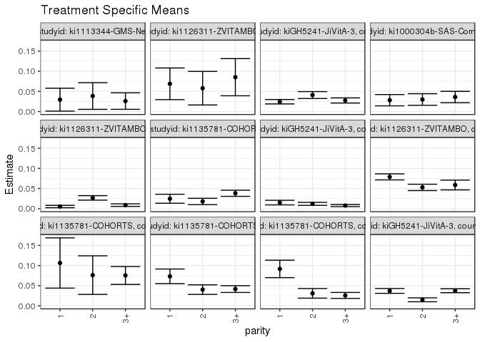

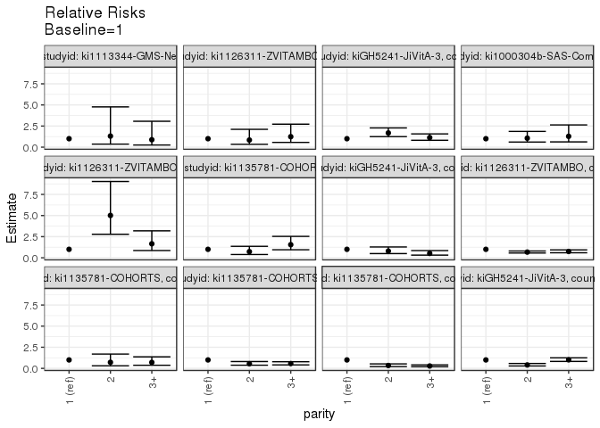

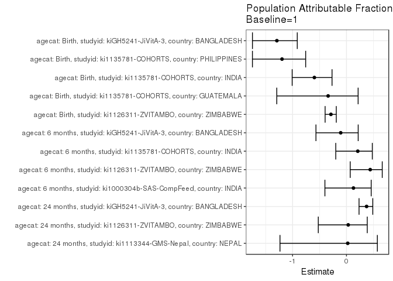

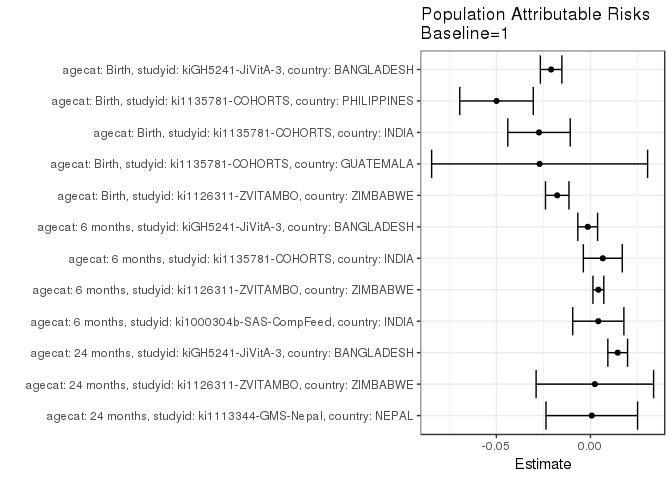

## Results Table

### Parameter: TSM

| agecat | studyid | country | intervention_level | baseline_level | estimate | ci_lower | ci_upper |
| --- | --- | --- | --- | --- | --- | --- | --- |
| Birth | ki1126311-ZVITAMBO | ZIMBABWE | 1 | NA | 0.0789062 | 0.0713712 | 0.0864411 |
| Birth | ki1126311-ZVITAMBO | ZIMBABWE | 2 | NA | 0.0528225 | 0.0449273 | 0.0607177 |
| Birth | ki1126311-ZVITAMBO | ZIMBABWE | 3+ | NA | 0.0587549 | 0.0466084 | 0.0709013 |
| Birth | ki1135781-COHORTS | GUATEMALA | 1 | NA | 0.1063830 | 0.0440119 | 0.1687541 |
| Birth | ki1135781-COHORTS | GUATEMALA | 2 | NA | 0.0762712 | 0.0283479 | 0.1241945 |
| Birth | ki1135781-COHORTS | GUATEMALA | 3+ | NA | 0.0753676 | 0.0531697 | 0.0975656 |
| Birth | ki1135781-COHORTS | INDIA | 1 | NA | 0.0732515 | 0.0550550 | 0.0914481 |
| Birth | ki1135781-COHORTS | INDIA | 2 | NA | 0.0402891 | 0.0284001 | 0.0521781 |
| Birth | ki1135781-COHORTS | INDIA | 3+ | NA | 0.0416795 | 0.0332827 | 0.0500762 |
| Birth | ki1135781-COHORTS | PHILIPPINES | 1 | NA | 0.0916634 | 0.0700313 | 0.1132955 |
| Birth | ki1135781-COHORTS | PHILIPPINES | 2 | NA | 0.0310385 | 0.0191035 | 0.0429735 |
| Birth | ki1135781-COHORTS | PHILIPPINES | 3+ | NA | 0.0258870 | 0.0184867 | 0.0332873 |
| Birth | kiGH5241-JiVitA-3 | BANGLADESH | 1 | NA | 0.0370885 | 0.0310868 | 0.0430901 |
| Birth | kiGH5241-JiVitA-3 | BANGLADESH | 2 | NA | 0.0150493 | 0.0102433 | 0.0198554 |
| Birth | kiGH5241-JiVitA-3 | BANGLADESH | 3+ | NA | 0.0375598 | 0.0326530 | 0.0424665 |
| 6 months | ki1000304b-SAS-CompFeed | INDIA | 1 | NA | 0.0280612 | 0.0140579 | 0.0420646 |
| 6 months | ki1000304b-SAS-CompFeed | INDIA | 2 | NA | 0.0298013 | 0.0154373 | 0.0441654 |
| 6 months | ki1000304b-SAS-CompFeed | INDIA | 3+ | NA | 0.0359375 | 0.0218263 | 0.0500487 |
| 6 months | ki1126311-ZVITAMBO | ZIMBABWE | 1 | NA | 0.0053467 | 0.0023990 | 0.0082944 |
| 6 months | ki1126311-ZVITAMBO | ZIMBABWE | 2 | NA | 0.0267955 | 0.0212333 | 0.0323577 |
| 6 months | ki1126311-ZVITAMBO | ZIMBABWE | 3+ | NA | 0.0088463 | 0.0056848 | 0.0120078 |
| 6 months | ki1135781-COHORTS | INDIA | 1 | NA | 0.0246991 | 0.0135791 | 0.0358191 |
| 6 months | ki1135781-COHORTS | INDIA | 2 | NA | 0.0178754 | 0.0100121 | 0.0257387 |
| 6 months | ki1135781-COHORTS | INDIA | 3+ | NA | 0.0382372 | 0.0306592 | 0.0458152 |
| 6 months | kiGH5241-JiVitA-3 | BANGLADESH | 1 | NA | 0.0151299 | 0.0093820 | 0.0208779 |
| 6 months | kiGH5241-JiVitA-3 | BANGLADESH | 2 | NA | 0.0120152 | 0.0083383 | 0.0156922 |
| 6 months | kiGH5241-JiVitA-3 | BANGLADESH | 3+ | NA | 0.0077848 | 0.0051354 | 0.0104341 |
| 24 months | ki1113344-GMS-Nepal | NEPAL | 1 | NA | 0.0294118 | 0.0009872 | 0.0578363 |
| 24 months | ki1113344-GMS-Nepal | NEPAL | 2 | NA | 0.0384615 | 0.0053706 | 0.0715525 |
| 24 months | ki1113344-GMS-Nepal | NEPAL | 3+ | NA | 0.0258621 | 0.0054173 | 0.0463068 |
| 24 months | ki1126311-ZVITAMBO | ZIMBABWE | 1 | NA | 0.0687500 | 0.0294970 | 0.1080030 |
| 24 months | ki1126311-ZVITAMBO | ZIMBABWE | 2 | NA | 0.0578512 | 0.0162040 | 0.0994985 |
| 24 months | ki1126311-ZVITAMBO | ZIMBABWE | 3+ | NA | 0.0851064 | 0.0389937 | 0.1312190 |
| 24 months | kiGH5241-JiVitA-3 | BANGLADESH | 1 | NA | 0.0242858 | 0.0187979 | 0.0297736 |
| 24 months | kiGH5241-JiVitA-3 | BANGLADESH | 2 | NA | 0.0408563 | 0.0323289 | 0.0493837 |
| 24 months | kiGH5241-JiVitA-3 | BANGLADESH | 3+ | NA | 0.0274116 | 0.0210460 | 0.0337773 |

### Parameter: E(Y)

| agecat | studyid | country | intervention_level | baseline_level | estimate | ci_lower | ci_upper |
| --- | --- | --- | --- | --- | --- | --- | --- |
| Birth | ki1126311-ZVITAMBO | ZIMBABWE | NA | NA | 0.0612466 | 0.0571111 | 0.0653822 |
| Birth | ki1135781-COHORTS | GUATEMALA | NA | NA | 0.0793651 | 0.0600839 | 0.0986462 |
| Birth | ki1135781-COHORTS | INDIA | NA | NA | 0.0459144 | 0.0393065 | 0.0525222 |
| Birth | ki1135781-COHORTS | PHILIPPINES | NA | NA | 0.0417385 | 0.0344572 | 0.0490198 |
| Birth | kiGH5241-JiVitA-3 | BANGLADESH | NA | NA | 0.0161866 | 0.0138216 | 0.0185515 |
| 6 months | ki1000304b-SAS-CompFeed | INDIA | NA | NA | 0.0322339 | 0.0235219 | 0.0409459 |
| 6 months | ki1126311-ZVITAMBO | ZIMBABWE | NA | NA | 0.0095607 | 0.0074624 | 0.0116590 |
| 6 months | ki1135781-COHORTS | INDIA | NA | NA | 0.0312719 | 0.0260599 | 0.0364838 |
| 6 months | kiGH5241-JiVitA-3 | BANGLADESH | NA | NA | 0.0136688 | 0.0115917 | 0.0157459 |
| 24 months | ki1113344-GMS-Nepal | NEPAL | NA | NA | 0.0301205 | 0.0150939 | 0.0451470 |
| 24 months | ki1126311-ZVITAMBO | ZIMBABWE | NA | NA | 0.0710900 | 0.0465431 | 0.0956370 |
| 24 months | kiGH5241-JiVitA-3 | BANGLADESH | NA | NA | 0.0387710 | 0.0344423 | 0.0430996 |

### Parameter: RR

| agecat | studyid | country | intervention_level | baseline_level | estimate | ci_lower | ci_upper |
| --- | --- | --- | --- | --- | --- | --- | --- |
| Birth | ki1126311-ZVITAMBO | ZIMBABWE | 1 | 1 | 1.0000000 | 1.0000000 | 1.0000000 |
| Birth | ki1126311-ZVITAMBO | ZIMBABWE | 2 | 1 | 0.6694344 | 0.5607327 | 0.7992088 |
| Birth | ki1126311-ZVITAMBO | ZIMBABWE | 3+ | 1 | 0.7446168 | 0.5930302 | 0.9349511 |
| Birth | ki1135781-COHORTS | GUATEMALA | 1 | 1 | 1.0000000 | 1.0000000 | 1.0000000 |
| Birth | ki1135781-COHORTS | GUATEMALA | 2 | 1 | 0.7169492 | 0.3035745 | 1.6932122 |
| Birth | ki1135781-COHORTS | GUATEMALA | 3+ | 1 | 0.7084559 | 0.3675932 | 1.3653943 |
| Birth | ki1135781-COHORTS | INDIA | 1 | 1 | 1.0000000 | 1.0000000 | 1.0000000 |
| Birth | ki1135781-COHORTS | INDIA | 2 | 1 | 0.5500102 | 0.3741516 | 0.8085258 |
| Birth | ki1135781-COHORTS | INDIA | 3+ | 1 | 0.5689911 | 0.4135590 | 0.7828408 |
| Birth | ki1135781-COHORTS | PHILIPPINES | 1 | 1 | 1.0000000 | 1.0000000 | 1.0000000 |
| Birth | ki1135781-COHORTS | PHILIPPINES | 2 | 1 | 0.3386137 | 0.2156126 | 0.5317834 |
| Birth | ki1135781-COHORTS | PHILIPPINES | 3+ | 1 | 0.2824140 | 0.1949555 | 0.4091071 |
| Birth | kiGH5241-JiVitA-3 | BANGLADESH | 1 | 1 | 1.0000000 | 1.0000000 | 1.0000000 |
| Birth | kiGH5241-JiVitA-3 | BANGLADESH | 2 | 1 | 0.4057685 | 0.2836356 | 0.5804915 |
| Birth | kiGH5241-JiVitA-3 | BANGLADESH | 3+ | 1 | 1.0127084 | 0.8219194 | 1.2477844 |
| 6 months | ki1000304b-SAS-CompFeed | INDIA | 1 | 1 | 1.0000000 | 1.0000000 | 1.0000000 |
| 6 months | ki1000304b-SAS-CompFeed | INDIA | 2 | 1 | 1.0620108 | 0.6052683 | 1.8634168 |
| 6 months | ki1000304b-SAS-CompFeed | INDIA | 3+ | 1 | 1.2806818 | 0.6228782 | 2.6331726 |
| 6 months | ki1126311-ZVITAMBO | ZIMBABWE | 1 | 1 | 1.0000000 | 1.0000000 | 1.0000000 |
| 6 months | ki1126311-ZVITAMBO | ZIMBABWE | 2 | 1 | 5.0116072 | 2.7808124 | 9.0319671 |
| 6 months | ki1126311-ZVITAMBO | ZIMBABWE | 3+ | 1 | 1.6545394 | 0.8579719 | 3.1906648 |
| 6 months | ki1135781-COHORTS | INDIA | 1 | 1 | 1.0000000 | 1.0000000 | 1.0000000 |
| 6 months | ki1135781-COHORTS | INDIA | 2 | 1 | 0.7237256 | 0.3857418 | 1.3578480 |
| 6 months | ki1135781-COHORTS | INDIA | 3+ | 1 | 1.5481209 | 0.9467451 | 2.5314927 |
| 6 months | kiGH5241-JiVitA-3 | BANGLADESH | 1 | 1 | 1.0000000 | 1.0000000 | 1.0000000 |
| 6 months | kiGH5241-JiVitA-3 | BANGLADESH | 2 | 1 | 0.7941349 | 0.4935393 | 1.2778117 |
| 6 months | kiGH5241-JiVitA-3 | BANGLADESH | 3+ | 1 | 0.5145279 | 0.3108647 | 0.8516212 |
| 24 months | ki1113344-GMS-Nepal | NEPAL | 1 | 1 | 1.0000000 | 1.0000000 | 1.0000000 |
| 24 months | ki1113344-GMS-Nepal | NEPAL | 2 | 1 | 1.3076923 | 0.3585620 | 4.7692142 |
| 24 months | ki1113344-GMS-Nepal | NEPAL | 3+ | 1 | 0.8793103 | 0.2522864 | 3.0647178 |
| 24 months | ki1126311-ZVITAMBO | ZIMBABWE | 1 | 1 | 1.0000000 | 1.0000000 | 1.0000000 |
| 24 months | ki1126311-ZVITAMBO | ZIMBABWE | 2 | 1 | 0.8414726 | 0.3357357 | 2.1090285 |
| 24 months | ki1126311-ZVITAMBO | ZIMBABWE | 3+ | 1 | 1.2379110 | 0.5634392 | 2.7197677 |
| 24 months | kiGH5241-JiVitA-3 | BANGLADESH | 1 | 1 | 1.0000000 | 1.0000000 | 1.0000000 |
| 24 months | kiGH5241-JiVitA-3 | BANGLADESH | 2 | 1 | 1.6823159 | 1.2437544 | 2.2755190 |
| 24 months | kiGH5241-JiVitA-3 | BANGLADESH | 3+ | 1 | 1.1287124 | 0.8118949 | 1.5691584 |

### Parameter: PAR

| agecat | studyid | country | intervention_level | baseline_level | estimate | ci_lower | ci_upper |
| --- | --- | --- | --- | --- | --- | --- | --- |
| Birth | ki1126311-ZVITAMBO | ZIMBABWE | 1 | NA | -0.0176595 | -0.0239026 | -0.0114165 |
| Birth | ki1135781-COHORTS | GUATEMALA | 1 | NA | -0.0270179 | -0.0844158 | 0.0303800 |
| Birth | ki1135781-COHORTS | INDIA | 1 | NA | -0.0273371 | -0.0439279 | -0.0107464 |
| Birth | ki1135781-COHORTS | PHILIPPINES | 1 | NA | -0.0499249 | -0.0694661 | -0.0303836 |
| Birth | kiGH5241-JiVitA-3 | BANGLADESH | 1 | NA | -0.0209019 | -0.0266153 | -0.0151884 |
| 6 months | ki1000304b-SAS-CompFeed | INDIA | 1 | NA | 0.0041727 | -0.0094235 | 0.0177689 |
| 6 months | ki1126311-ZVITAMBO | ZIMBABWE | 1 | NA | 0.0042140 | 0.0013274 | 0.0071006 |
| 6 months | ki1135781-COHORTS | INDIA | 1 | NA | 0.0065728 | -0.0037762 | 0.0169217 |
| 6 months | kiGH5241-JiVitA-3 | BANGLADESH | 1 | NA | -0.0014611 | -0.0067171 | 0.0037948 |
| 24 months | ki1113344-GMS-Nepal | NEPAL | 1 | NA | 0.0007087 | -0.0236318 | 0.0250492 |
| 24 months | ki1126311-ZVITAMBO | ZIMBABWE | 1 | NA | 0.0023400 | -0.0288845 | 0.0335646 |
| 24 months | kiGH5241-JiVitA-3 | BANGLADESH | 1 | NA | 0.0144852 | 0.0092436 | 0.0197268 |

### Parameter: PAF

| agecat | studyid | country | intervention_level | baseline_level | estimate | ci_lower | ci_upper |
| --- | --- | --- | --- | --- | --- | --- | --- |
| Birth | ki1126311-ZVITAMBO | ZIMBABWE | 1 | NA | -0.2883350 | -0.3961256 | -0.1888666 |
| Birth | ki1135781-COHORTS | GUATEMALA | 1 | NA | -0.3404255 | -1.2928794 | 0.2163824 |
| Birth | ki1135781-COHORTS | INDIA | 1 | NA | -0.5953939 | -1.0076516 | -0.2677905 |
| Birth | ki1135781-COHORTS | PHILIPPINES | 1 | NA | -1.1961339 | -1.7450119 | -0.7570066 |
| Birth | kiGH5241-JiVitA-3 | BANGLADESH | 1 | NA | -1.2913073 | -1.7446546 | -0.9128414 |
| 6 months | ki1000304b-SAS-CompFeed | INDIA | 1 | NA | 0.1294495 | -0.4000328 | 0.4586853 |
| 6 months | ki1126311-ZVITAMBO | ZIMBABWE | 1 | NA | 0.4407637 | 0.0697054 | 0.6638213 |
| 6 months | ki1135781-COHORTS | INDIA | 1 | NA | 0.2101814 | -0.1984492 | 0.4794828 |
| 6 months | kiGH5241-JiVitA-3 | BANGLADESH | 1 | NA | -0.1068964 | -0.5659871 | 0.2176055 |
| 24 months | ki1113344-GMS-Nepal | NEPAL | 1 | NA | 0.0235294 | -1.2337547 | 0.5731426 |
| 24 months | ki1126311-ZVITAMBO | ZIMBABWE | 1 | NA | 0.0329167 | -0.5228379 | 0.3858505 |
| 24 months | kiGH5241-JiVitA-3 | BANGLADESH | 1 | NA | 0.3736100 | 0.2333602 | 0.4882024 |